# Incarceration Data Visualization

# Summary

The data set I am analyzing contains incarceration information from 1970 to 2018. The data set contains variables such as:  
yfips, year, fips, state, county_name, total_pop, total_pop_15to64, female_pop_15to64, male_pop_15to64, aapi_pop_15to64, black_pop_15to64, latinx_pop_15to64, native_pop_15to64, white_pop_15to64, urbanicity, region, division, commuting_zone, metro_area, land_area, total_jail_pop, female_jail_pop, male_jail_pop, female_adult_jail_pop, female_juvenile_jail_pop, male_adult_jail_pop, male_juvenile_jail_pop, aapi_jail_pop, black_jail_pop, latinx_jail_pop, native_jail_pop, white_jail_pop, other_race_jail_pop, total_jail_pretrial, total_jail_from_prison, total_jail_from_other_jail, total_jail_from_fed, total_jail_from_bia, total_jail_from_bop, total_jail_from_ice, total_jail_from_marshals, total_jail_from_other_fed, jail_rated_capacity, private_jail_flag, regional_jail_flag, total_jail_adm, total_jail_dis, total_jail_pop_dcrp, female_jail_pop_dcrp, male_jail_pop_dcrp, total_jail_adm_dcrp, female_jail_adm_dcrp, male_jail_adm_dcrp, total_prison_pop, female_prison_pop, male_prison_pop, aapi_prison_pop, black_prison_pop, latinx_prison_pop, native_prison_pop, other_race_prison_pop, white_prison_pop, aapi_female_prison_pop, aapi_male_prison_pop, black_female_prison_pop, black_male_prison_pop, latinx_female_prison_pop, latinx_male_prison_pop, native_female_prison_pop, native_male_prison_pop, other_race_female_prison_pop, other_race_male_prison_pop, white_female_prison_pop, white_male_prison_pop, total_prison_adm, female_prison_adm, male_prison_adm, aapi_prison_adm, black_prison_adm, latinx_prison_adm, native_prison_adm, other_race_prison_adm, white_prison_adm, aapi_female_prison_adm, aapi_male_prison_adm, black_female_prison_adm, black_male_prison_adm, latinx_female_prison_adm, latinx_male_prison_adm, native_female_prison_adm, native_male_prison_adm, other_race_female_prison_adm, other_race_male_prison_adm, white_female_prison_adm, white_male_prison_adm, total_jail_pop_rate, female_jail_pop_rate, male_jail_pop_rate, aapi_jail_pop_rate, black_jail_pop_rate, latinx_jail_pop_rate, native_jail_pop_rate, white_jail_pop_rate, total_jail_adm_rate, total_jail_pretrial_rate, total_prison_pop_rate, female_prison_pop_rate, male_prison_pop_rate, aapi_prison_pop_rate, black_prison_pop_rate, latinx_prison_pop_rate, native_prison_pop_rate, white_prison_pop_rate, total_prison_adm_rate, female_prison_adm_rate, male_prison_adm_rate, aapi_prison_adm_rate, black_prison_adm_rate, latinx_prison_adm_rate, native_prison_adm_rate, white_prison_adm_rate  
I will only be looking at the prison and jail population in relation to by gender. These data are collected for 51 states and 1876 counties.

# Prison Proportion Trends

This chart shows the total prison population proportion for males and females.

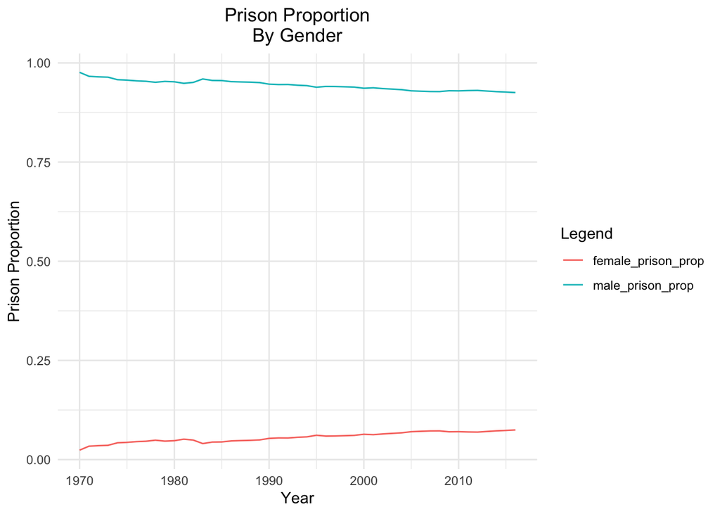

Males are overwhelmingly the larger proportion in the population. However, females are steadily increasing in proportion while males are steadily dropping.

# Female Male Comparison

However, males still largely outnumber females in prison populations. To view this disparity. I retrieved the 2016 prison populations and grouped them by sex.

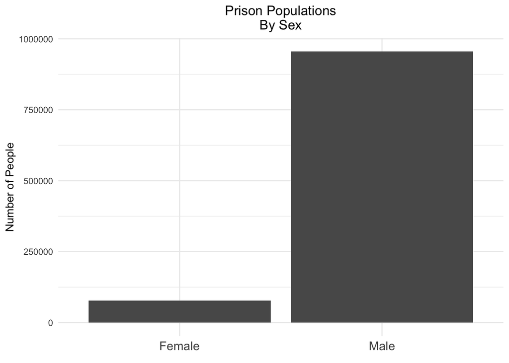

As you can see, the chart shows that males are greatly outnumbering females. This is only 2016 counts, but every year before this is also a large difference.

# State Map Ratio

I wanted to see which states were the contributors to males dominating the prison population. To do so I divided the males in prison by the females in prison then grouped them by state. The areas in the map that are blank had no information about them.

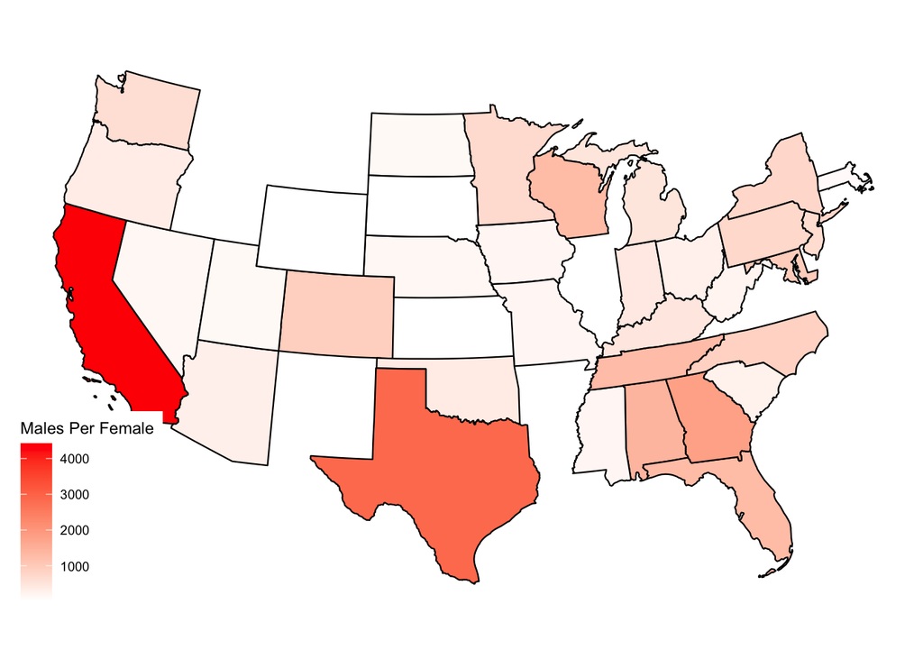

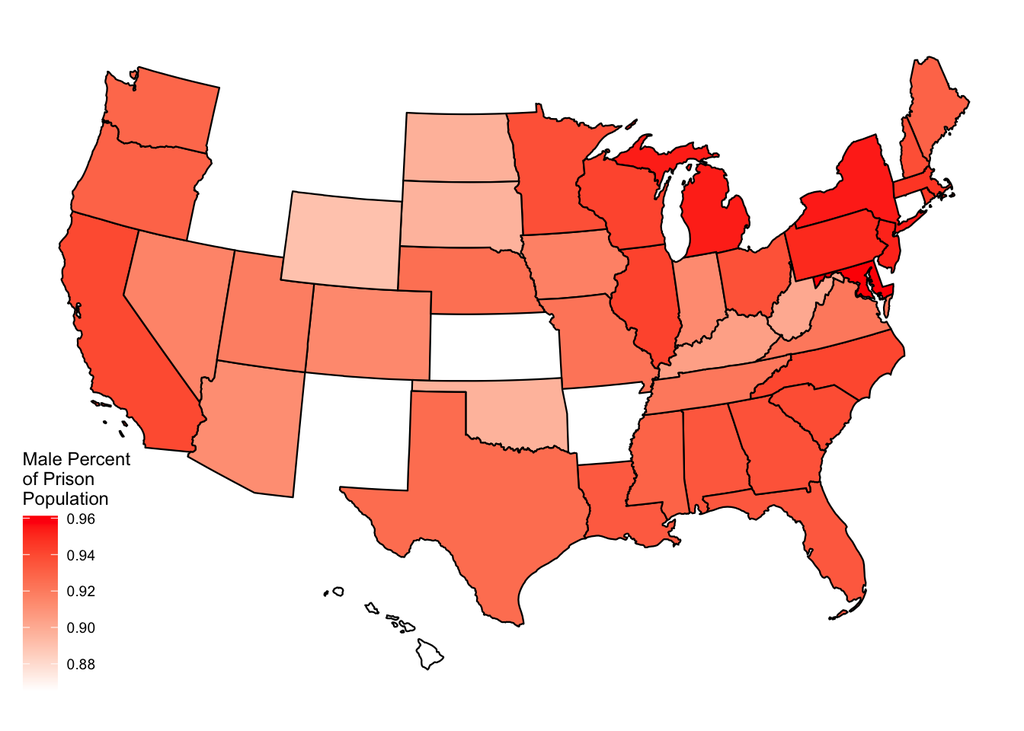

Ah, now instead of most of the offending areas being in Texas and California, it is now mostly in the North East region of the map.